# PD 11 - poprawienie pracy

Kamil Kmita

16 stycznia 2018

## Opis

W swojej pracy domowej postanowiłem poprawić [pracę domową nr 02](https://github.com/pbiecek/TechnikiWizualizacjiDanych2017/tree/master/PraceDomowe/PD_02/Kalinowska%20Maja%20PD2) autorstwa Mai Kalinowskiej. Dotyczyła ona [artykułu](https://businessinsider.com.pl/twoje-pieniadze/budzet-domowy/ile-polacy-wyrzucaja-jedzenia-raport-pazdziernik-2017/7285v6k) z portalu `businessinsider.com` opisującego wyniki badania `Kantar Millward Brown` na zlecenie `Federacji Polskich Banków Żywności`. Wykres, który Maja postanowiła poprawić, ukazywał grupy produktów najczęściej wskazywane jako te, które były wyrzucane przez respondentów. Prezentuje się on następująco:

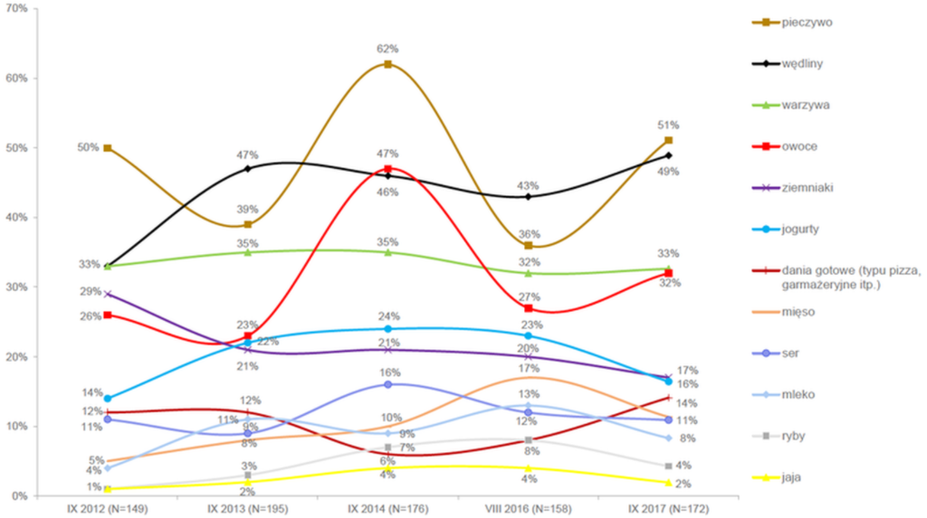

## Podejście Mai

Zmieniła ona całkowicie podejście do ukazania tej historii:

- uznała, że na wykresie jest za dużo linii i jest przez to nieczytelny
- przekształciła dane: ukazała odsetek odpowiedzi dla danej kategorii w poszczególnych latach (1 wykres - 1 rok) dodając informację o procentowej zmianie względem zeszłego roku

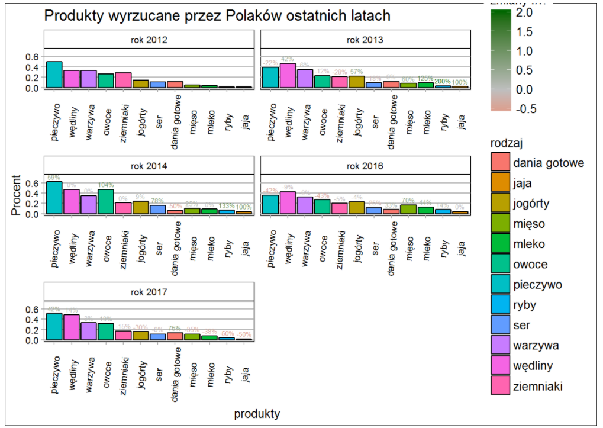